# R Notebook

```r
library(tidyverse)
library(readr)
library(ggplot2)
```

1. Load in the dataset and call it drinks_content, eyeball it by printing it out (first 5 rows, last 5 rows, and then all of the data) and find out the dimensions (number of rows/columns) and variable names.

```r
drinks_content <- read_csv("data/starbucks_drinkMenu_expanded.csv")
```

```r
dim(drinks_content)
```

```
[1] 242  18
```

```r
names(drinks_content)
```

```
 [1] "Beverage_category"       "Beverage"
 [3] "Beverage_prep"           "Calories"
 [5] "Total Fat (g)"           "Trans Fat (g)"
 [7] "Saturated Fat (g)"       "Sodium (mg)"
 [9] "Total Carbohydrates (g)" "Cholesterol (mg)"
[11] "Dietary Fibre (g)"       "Sugars (g)"
[13] "Protein (g)"             "Vitamin A (% DV)"
[15] "Vitamin C (% DV)"        "Calcium (% DV)"
[17] "Iron (% DV)"             "Caffeine (mg)"
```

```r
head(drinks_content, 5)
```

| Beverage_category | Beverage | Beverage_prep | Calories | Total Fat (g) | Trans Fat (g) | Saturated Fat (g) | Sodium (mg) | Total Carbohydrates (g) | Cholesterol (mg) | Dietary Fibre (g) | Sugars (g) | Protein (g) | Vitamin A (% DV) | Vitamin C (% DV) | Calcium (% DV) | Iron (% DV) | Caffeine (mg) |
| --- | --- | --- | --- | --- | --- | --- | --- | --- | --- | --- | --- | --- | --- | --- | --- | --- | --- |
| Coffee | Brewed Coffee | Short | 3 | 0.1 | 0.0 | 0 | 0 | 5 | 0 | 0 | 0 | 0.3 | 0% | 0% | 0% | 0% | 175 |
| Coffee | Brewed Coffee | Tall | 4 | 0.1 | 0.0 | 0 | 0 | 10 | 0 | 0 | 0 | 0.5 | 0% | 0% | 0% | 0% | 260 |
| Coffee | Brewed Coffee | Grande | 5 | 0.1 | 0.0 | 0 | 0 | 10 | 0 | 0 | 0 | 1.0 | 0% | 0% | 0% | 0% | 330 |
| Coffee | Brewed Coffee | Venti | 5 | 0.1 | 0.0 | 0 | 0 | 10 | 0 | 0 | 0 | 1.0 | 0% | 0% | 2% | 0% | 410 |
| Classic Espresso Drinks | Caffè Latte | Short Nonfat Milk | 70 | 0.1 | 0.1 | 0 | 5 | 75 | 10 | 0 | 9 | 6.0 | 10% | 0% | 20% | 0% | 75 |

```r
tail(drinks_content, 5)
```

| Beverage_category | Beverage | Beverage_prep | Calories | Total Fat (g) | Trans Fat (g) | Saturated Fat (g) | Sodium (mg) | Total Carbohydrates (g) | Cholesterol (mg) | Dietary Fibre (g) | Sugars (g) | Protein (g) | Vitamin A (% DV) | Vitamin C (% DV) | Calcium (% DV) | Iron (% DV) | Caffeine (mg) |
| --- | --- | --- | --- | --- | --- | --- | --- | --- | --- | --- | --- | --- | --- | --- | --- | --- | --- |
| Frappuccino® Blended Crème | Strawberries & Crème (Without Whipped Cream) | Soymilk | 320 | 3 2 | 0.4 | 0.0 | 0 | 250 | 67 | 1 | 64 | 5 | 6% | 8% | 20% | 10% | 0 |
| Frappuccino® Blended Crème | Vanilla Bean (Without Whipped Cream) | Tall Nonfat Milk | 170 | 0.1 | 0.1 | 0.0 | 0 | 160 | 39 | 0 | 38 | 4 | 6% | 0% | 10% | 0% | 0 |
| Frappuccino® Blended Crème | Vanilla Bean (Without Whipped Cream) | Whole Milk | 200 | 3.5 | 2.0 | 0.1 | 10 | 160 | 39 | 0 | 38 | 3 | 6% | 0% | 10% | 0% | 0 |
| Frappuccino® Blended Crème | Vanilla Bean (Without Whipped Cream) | Soymilk | 180 | 1.5 | 0.2 | 0.0 | 0 | 160 | 37 | 1 | 35 | 3 | 4% | 0% | 10% | 6% | 0 |
| Frappuccino® Blended Crème | Vanilla Bean (Without Whipped Cream) | Grande Nonfat Milk | 240 | 0.1 | 0.1 | 0.0 | 5 | 230 | 56 | 0 | 55 | 5 | 8% | 0% | 15% | 0% | 0 |

2. Calculate some quick summary statistics to check the mean, the variance, and the normality of this variable.

```r
summarise(drinks_content, mean(Calories), var(Calories))
```

| mean(Calories) | var(Calories) |
| --- | --- |
| 193.8719 | 10580.86 |

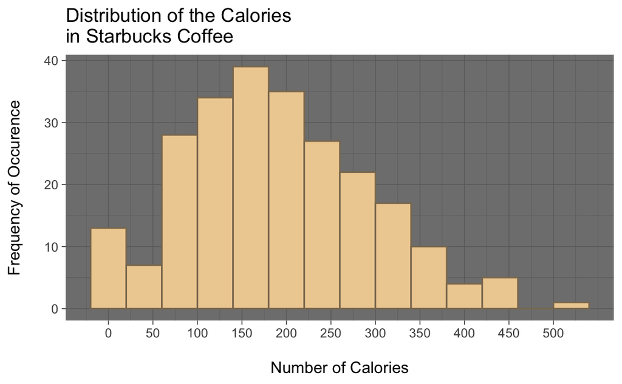

```r
ggplot(drinks_content) +
  aes(x = Calories) +
  geom_histogram(binwidth = 40, fill = "navajowhite2", colour = "navajowhite4") +
  scale_x_continuous(breaks = seq(0, 500, 50)) +
  labs(
    x = "\nNumber of Calories",
    y = "Frequency of Occurence\n",
    title = "Distribution of the Calories\nin Starbucks Coffee"
  ) +
  theme_dark()
```

```r
NA
```

3. Check if you have any outliers in the Calories variable by creating a boxplot. Then get the actual values of any outliers you have. Finally remove the outliers and save the new tibble as drinks_content_nooutlier

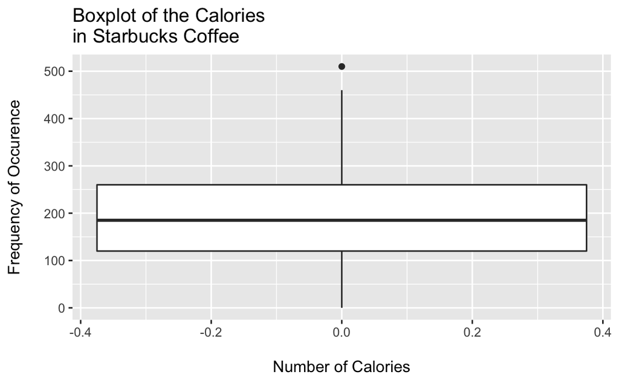

```r
ggplot(drinks_content) +
  aes(y = Calories) +
  geom_boxplot() +
  labs(
    x = "\nNumber of Calories",
    y = "Frequency of Occurence\n",
    title = "Boxplot of the Calories\nin Starbucks Coffee"
  )
```

```r
outliers <- boxplot(drinks_content$Calories,
                    plot = FALSE)$out
drinks_content[which(drinks_content$Calories %in% outliers), ]
```

| Beverage_category | Beverage | Beverage_prep | Calories | Total Fat (g) | Trans Fat (g) | Saturated Fat (g) | Sodium (mg) | Total Carbohydrates (g) | Cholesterol (mg) | Dietary Fibre (g) | Sugars (g) | Protein (g) | Vitamin A (% DV) | Vitamin C (% DV) | Calcium (% DV) | Iron (% DV) | Caffeine (mg) |
| --- | --- | --- | --- | --- | --- | --- | --- | --- | --- | --- | --- | --- | --- | --- | --- | --- | --- |
| Signature Espresso Drinks | White Chocolate Mocha (Without Whipped Cream) | 2% Milk | 510 | 15 | 9 | 0.2 | 35 | 330 | 77 | 0 | 74 | 19 | 20% | 4% | 60% | 2% | 150 |

```r
drinks_content_nooutlier <- drinks_content[-which(drinks_content$Calories %in% outliers), ]
```

4. Select the variables beverage_category, beverage, beverage prep and calories from the data (drinks_content_nooutlier), and assign it to a new tibble called drinks. Since we are interested in the calorie content, check if there are any NA values in the data, and drop them if there are

```r
drinks <- select(drinks_content_nooutlier, Beverage_category, Beverage,
                 Beverage_prep, Calories)
sum(is.na(drinks$Calories))
```

```
[1] 0
```

```r
unique(drinks$Calories)
```

```
 [1]   3   4   5  70 100 150 110 130 190 170 240 200 180 220 260 230 280 340
[19] 290 160 250 210 320 270  10  15  25  50  80  60  90 120 140 300 310 350
[37] 400 370 450 460 380 330 360   0 390 420 430
```

5. Filter the data so we only take “classic espresso drinks”, and save this in a new tibble called espresso_drinks

```r
espresso_drinks <- filter(drinks,
                          Beverage_category == "Classic Espresso Drinks")
```

6. Create a new tibble called drink_calories which contains a variable called calorie_diff. calorie_diff should store the difference between 135 calories (135 calories = 10 cubes of sugar!) and the calories in each drink. (hint: you’ll want to subtract the calories from 135 to see which drink have more or less than 10 cups of sugar).

```r
drinks_calories <- mutate(espresso_drinks, calorie_diff = 135 - Calories)
```

```r
drinks_grouped <- group_by(drinks_calories, Beverage)
drinks_summary<- summarise(drinks_grouped, mean_cal = mean(Calories))
arrange(drinks_summary, desc(mean_cal))
```

| Beverage | mean_cal |
| --- | --- |
| Caffè Mocha (Without Whipped Cream) | 210.0000 |
| Vanilla Latte (Or Other Flavoured Latte) | 195.8333 |
| Caffè Latte | 139.1667 |
| Skinny Latte (Any Flavour) | 110.0000 |
| Cappuccino | 90.0000 |
| Caffè Americano | 13.7500 |
| Espresso | 7.5000 |

Finish up by using the %>% operator to put all the answers you’ve got from questions 4-7 into one pipe. You don’t need to include the check for NA values in this, as you’d typically check that before you start doing any analysis.

```r
pipe_drinks <- drinks_content_nooutlier %>%
  select(Beverage_category, Beverage, Beverage_prep, Calories) %>%
  filter(Beverage_category == "Classic Espresso Drinks") %>%
  mutate(calorie_diff = 135 - Calories) %>%
  group_by(Beverage) %>%
  summarise(mean_cal = mean(Calories)) %>%
  arrange(desc(mean_cal))
```

Use the drink_calories data, and for each drink, use the min_rank function to find the two drinks (Beverage) with most Calories. Save this in a new tibble called most_calories.

```r
most_calories <- drinks_calories %>%
  group_by(Beverage) %>%
   filter(min_rank(desc(Calories)) %in% c(1,2))
```

For each drink in the drinks_grouped data, find all drinks which more calories than the average drink. Save this in a new tibble called above_average_calories.

```r
above_average_calories <- drinks_grouped %>%
  group_by(Beverage) %>%
  filter(Calories > mean(Calories))
```

Within each drink group, rank each beverage by the number of calories. Save this ranking in a new column called ranking. Save the new output in a new tibble called drinks_ranked.

```r
drinks_ranked <- drinks %>%
  group_by(Beverage_category) %>%
  mutate(ranking = min_rank(Calories)) %>%
  arrange(ranking)
```

```r
drinks_distribution <- drinks_grouped %>%
  arrange(Calories) %>%
  mutate(cumul_dist = cume_dist(Calories)) %>%
  filter(cumul_dist < 0.25)
```